# Task 4

## #1

```r
library(tidyverse)

#reading in dataframes
state_elev <- read.csv("./task_4/messy_state_elev.csv")
us_pop <- read.csv("./task_4/us-pop.csv",skip = 4)
us_temp <- read.csv("./task_4/us-temp-dec-june.csv")

## #1

#removing rows with NA
us_temp <- us_temp[1:48,]

us_temp$diff_june_22 <- us_temp$june_2022 - us_temp$june_means
us_temp$diff_june_23 <- us_temp$june_2023 - us_temp$june_means

us_temp$diff_dec_22 <- us_temp$december_2022 - us_temp$december_means
us_temp$diff_dec_23 <- us_temp$december_2023 - us_temp$december_means

us_temp <- us_temp[order(us_temp$diff_dec_22), ]
```

List of top 5 highest temperature differences in December of 2022

```r
#looking at the highest temperatures above the average
us_temp %>%
  select(name,diff_dec_22) %>%
  tail(5)
```

```
##             name diff_dec_22
## 37  Rhode Island         4.5
## 19 Massachusetts         5.0
## 27 New Hampshire         6.6
## 43       Vermont         7.0
## 17         Maine         8.9
```

List of top 5 highest temperature differences in December of 2023

```r
#now lets order by 2023 and get the top and lowest 5
us_temp <- us_temp[order(us_temp$diff_dec_23), ]

#looking at the highest temperatures above the average
us_temp %>%
  select(name,diff_dec_23) %>%
  tail(5)
```

```
##            name diff_dec_23
## 20     Michigan        12.0
## 13         Iowa        12.0
## 32 North Dakota        14.1
## 47    Wisconsin        14.2
## 21    Minnesota        17.1
```

Highest June 2022 anomaly in the **Midwest**

```r
#state in each region with highest june anomaly
us_temp %>%
  filter(region == "Midwest") %>%
  arrange(desc(diff_june_22)) %>%
  head(1) %>%
  select(name, diff_june_22)
```

```
##       name diff_june_22
## 1 Nebraska          3.1
```

Highest June 2022 anomaly in the **South**

```r
us_temp %>%
  filter(region == "South") %>%
  arrange(desc(diff_june_22)) %>%
  head(1) %>%
  select(name, diff_june_22)
```

```
##    name diff_june_22
## 1 Texas          4.2
```

Highest June 2022 anomaly in the **West**

```r
us_temp %>%
  filter(region == "West") %>%
  arrange(desc(diff_june_22)) %>%
  head(1) %>%
  select(name, diff_june_22)
```

```
##      name diff_june_22
## 1 Arizona          4.2
```

Highest June 2022 anomaly in the **Northeast**

```r
us_temp %>%
  filter(region == "Northeast") %>%
  arrange(desc(diff_june_22)) %>%
  head(1) %>%
  select(name, diff_june_22)
```

```
##           name diff_june_22
## 1 Rhode Island          1.6
```

Highest June 2023 anomaly in the **Midwest**

```r
#now lets do it for 2023
us_temp %>%
  filter(region == "Midwest") %>%
  arrange(desc(diff_june_23)) %>%
  head(1)%>%
  select(name, diff_june_23)
```

```
##           name diff_june_23
## 1 North Dakota          6.4
```

Highest June 2023 anomaly in the **South**

```r
us_temp %>%
  filter(region == "South") %>%
  arrange(desc(diff_june_23)) %>%
  head(1) %>%
  select(name, diff_june_23)
```

```
##    name diff_june_23
## 1 Texas          2.7
```

Highest June 2023 anomaly in the **West**

```r
us_temp %>%
  filter(region == "West") %>%
  arrange(desc(diff_june_23)) %>%
  head(1) %>%
  select(name, diff_june_23)
```

```
##         name diff_june_23
## 1 Washington          3.1
```

Highest June 2023 anomaly in the **Northeast**

```r
us_temp %>%
  filter(region == "Northeast") %>%
  arrange(desc(diff_june_23)) %>%
  head(1) %>%
  select(name, diff_june_23)
```

```
##      name diff_june_23
## 1 Vermont          0.7
```

## #2

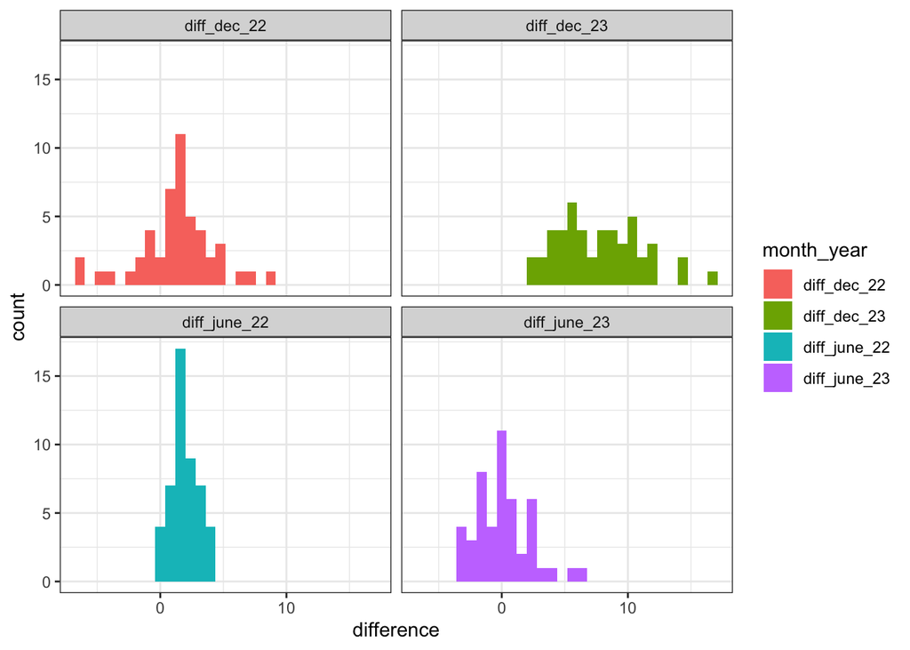

```r
us_temp_long <- pivot_longer(us_temp, cols = starts_with("diff"),
                             names_to = "month_year",
                             values_to = "difference")

us_temp_long %>%
  ggplot(aes(x=difference,fill = month_year)) +
  geom_histogram() +
  facet_wrap(~month_year) +
  theme_bw()
```

```r
# next tuesday ----

# pivot tables
# facet wrap
```

## #3

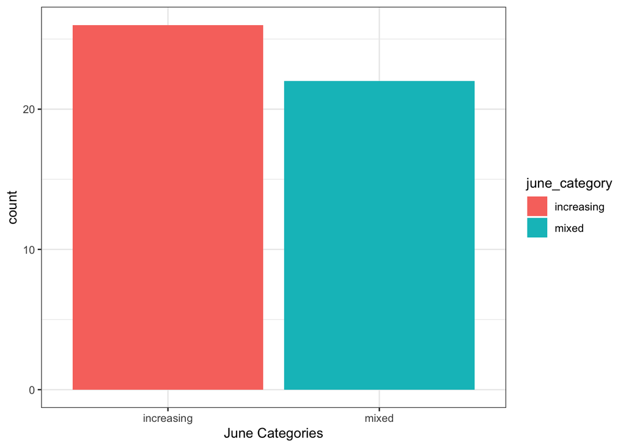

```r
for (i in 1:nrow(us_temp)) {
  if (us_temp$diff_june_22[i] > 0 & us_temp$diff_june_23[i] > 0 ) {
    us_temp$june_category[i] = "increasing"
  } else if(us_temp$diff_june_22[i] < 0 & us_temp$diff_june_23[i] < 0){
    us_temp$june_category[i] = "decreasing"
  } else if((us_temp$diff_june_22[i] < 0 & us_temp$diff_june_23[i] > 0) | (us_temp$diff_june_22[i] > 0 & us_temp$diff_june_23[i] < 0)){
    us_temp$june_category[i] = "mixed"
  }
}

for (i in 1:nrow(us_temp)) {
  if (us_temp$diff_dec_22[i] > 0 & us_temp$diff_dec_23[i] > 0 ) {
    us_temp$dec_category[i] = "increasing"
  } else if(us_temp$diff_dec_22[i] < 0 & us_temp$diff_dec_23[i] < 0){
    us_temp$dec_category[i] = "decreasing"
  } else if((us_temp$diff_dec_22[i] < 0 & us_temp$diff_dec_23[i] > 0) | (us_temp$diff_dec_22[i] > 0 & us_temp$diff_dec_23[i] < 0)){
    us_temp$dec_category[i] = "mixed"
  }
}

us_temp %>%
  ggplot(aes(x=june_category,fill=june_category)) +
  geom_bar() +
  theme_bw() +
  labs(x="June Categories")
```

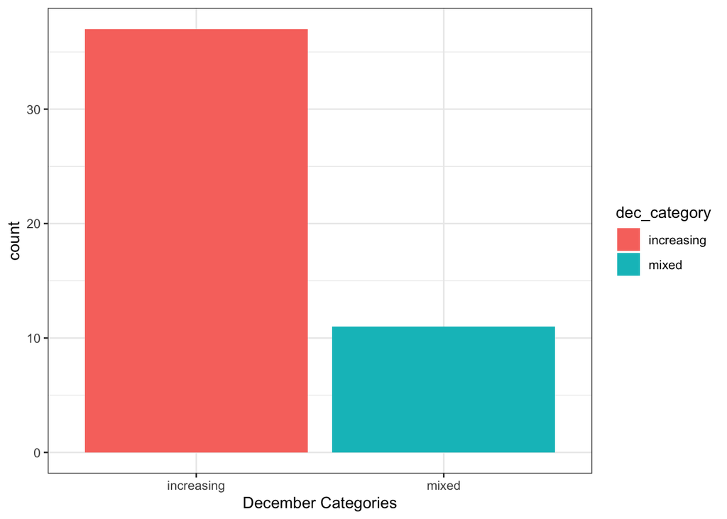

```r
us_temp %>%
  ggplot(aes(x=dec_category,fill=dec_category)) +
  geom_bar() +
  theme_bw() +
  labs(x="December Categories")
```

## #4

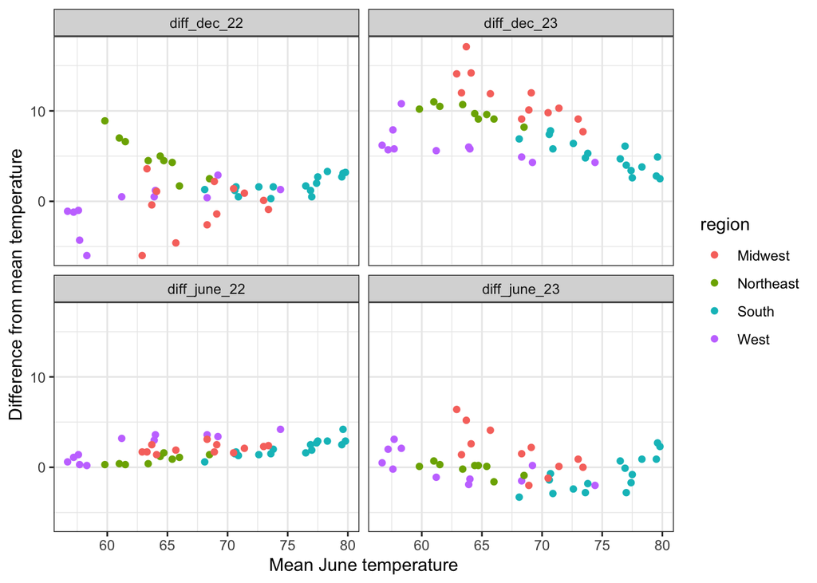

```r
us_temp_long %>%
  ggplot(aes(x=june_means,y=difference,color=region)) +
  geom_point() +
  facet_wrap(~month_year) +
  theme_bw() +
  labs(x="Mean June temperature",
       y="Difference from mean temperature")
```

The regions temperatures definitely stay in clusters. It seems the Northeast and the Midwest have the highest anomalies.

## #5

Using the above graphs it seems that 2022 has a colder winter than 2023 but 2023 had a colder summer than 2022

## #6

```r
#changing column names
names(state_elev) <- c("state","max_elev_location","max_elev_county","max_elev_ft","min_elev_location","min_elev_county","min_elev_ft")

#remove special characters
#removing anything between the brackets AND the brackets
state_elev$min_elev_ft <- gsub("\\{.*\\}","",state_elev$min_elev_ft)

#replace Sea level with 0
state_elev$min_elev_ft <- gsub("Sea level",0,state_elev$min_elev_ft)

#replace Sea Level with 0
state_elev$min_elev_ft <- gsub("Sea Level",0,state_elev$min_elev_ft)

#removing commas
state_elev$min_elev_ft <- gsub(",","",state_elev$min_elev_ft)

#changing numeric columns to the correct class
state_elev$min_elev_ft <- as.numeric(state_elev$min_elev_ft)


#lets repeat these steps for the other elevation column
#removing anything between the brackets AND the brackets
state_elev$max_elev_ft <- gsub("\\{.*\\}","",state_elev$max_elev_ft)

#removing commas
state_elev$max_elev_ft<- gsub(",","",state_elev$max_elev_ft)

#changing numeric columns to the correct class
state_elev$max_elev_ft <- as.numeric(state_elev$max_elev_ft)

#changing - - to NA
state_elev[state_elev == "- -"] <- NA

#making elevation range column
state_elev$elev_range = state_elev$max_elev_ft - state_elev$min_elev_ft

summary(state_elev)
```

```
##     state           max_elev_location  max_elev_county     max_elev_ft
##  Length:56          Length:56          Length:56          Min.   :  345
##  Class :character   Class :character   Class :character   1st Qu.: 1914
##  Mode  :character   Mode  :character   Mode  :character   Median : 4268
##                                                           Mean   : 6059
##                                                           3rd Qu.: 9372
##                                                           Max.   :20320
##  min_elev_location  min_elev_county     min_elev_ft       elev_range
##  Length:56          Length:56          Min.   :-282.0   Min.   :  345
##  Class :character   Class :character   1st Qu.:   0.0   1st Qu.: 1552
##  Mode  :character   Mode  :character   Median :   0.0   Median : 4093
##                                        Mean   : 385.9   Mean   : 5673
##                                        3rd Qu.: 479.2   3rd Qu.: 9142
##                                        Max.   :3315.0   Max.   :20602
```

```r
head(state_elev)
```

```
##        state max_elev_location max_elev_county max_elev_ft min_elev_location
## 1    Alabama   Cheaha Mountain        Cleburne        2407    Gulf of Mexico
## 2     Alaska            Denali            <NA>       20320     Pacific Ocean
## 3    Arizona    Humphreys Peak        Coconino       12633    Colorado River
## 4   Arkansas Magazine Mountain           Logan        2753    Ouachita River
## 5 California     Mount Whitney     Inyo-Tulare       14494      Death Valley
## 6   Colorado      Mount Elbert            Lake       14433    Arikaree River
##   min_elev_county min_elev_ft elev_range
## 1            <NA>           0       2407
## 2            <NA>           0      20320
## 3            Yuma          70      12563
## 4    Ashley-Union          55       2698
## 5            Inyo        -282      14776
## 6            Yuma        3315      11118
```

## #7

Looking at the top 10 States with the greatest increase in population from 2010 to 2020:

```r
#renaming X to state
us_pop <- us_pop %>%
  rename(state = X)

#removing unnecessary bottom rows
us_pop <- us_pop[1:57,]

#removing commas through the entire dataframe
us_pop <- mutate_all(us_pop, ~gsub(",", "", .))

#turning all columns except the state into numeric
us_pop[, 2:6] <- lapply(us_pop[, 2:6], as.numeric)

#calculating percent change between each decade
us_pop$percent_change_2020 = ((us_pop$Resident.Population.2020.Census /us_pop$Resident.Population.2010.Census)-1) * 100
us_pop$percent_change_2010 = ((us_pop$Resident.Population.2010.Census /us_pop$Resident.Population.2000.Census)-1) * 100
us_pop$percent_change_2000 = ((us_pop$Resident.Population.2000.Census /us_pop$Resident.Population.1990.Census)-1) * 100
us_pop$percent_change_1990 = ((us_pop$Resident.Population.1990.Census /us_pop$Resident.Population.1980.Census)-1) * 100

#looking at 10 max percentage changes and the states
us_pop[order(us_pop$percent_change_2020, decreasing = TRUE), ][1:10,c(1,7)]
```

```
##                   state percent_change_2020
## 45                 Utah            18.37019
## 13                Idaho            17.32120
## 44                Texas            15.90716
## 35         North Dakota            15.83473
## 29               Nevada            14.96224
## 6              Colorado            14.80392
## 9  District of Columbia            14.59509
## 48           Washington            14.58451
## 10              Florida            14.55684
## 3               Arizona            11.88177
```

## #8

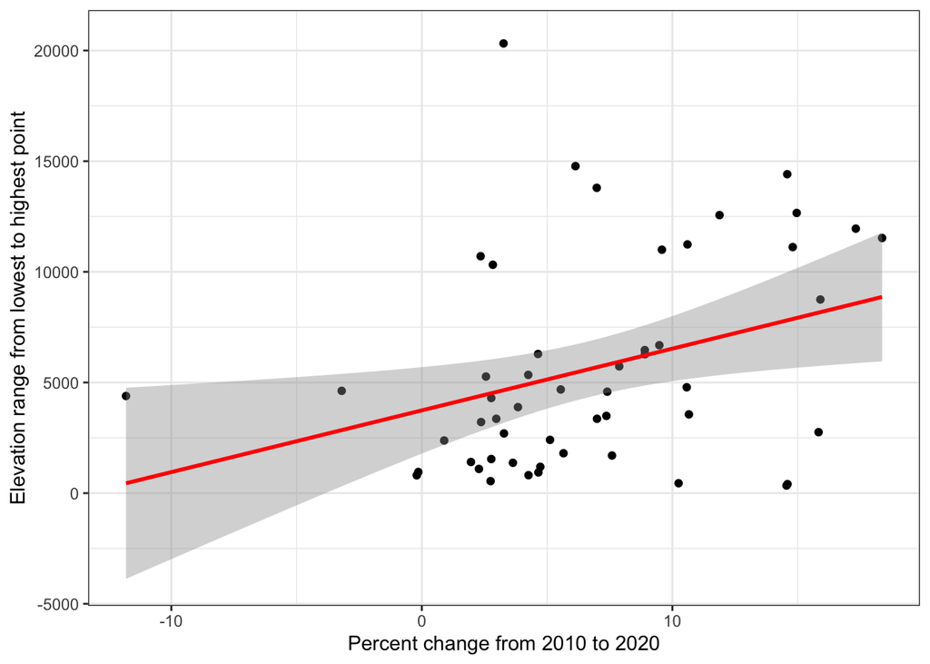

```r
pop_elev <- full_join(us_pop,state_elev)

pop_elev %>%
  ggplot(aes(x = percent_change_2020, y = elev_range)) +
  geom_point() +
  geom_smooth(method = "lm", se = TRUE, color = "red") +  # Add linear model line
  theme_bw() +
  labs(x="Percent change from 2010 to 2020",
       y="Elevation range from lowest to highest point")
```

```r
#creating the linear model to look at the numbers
model <- lm(percent_change_2020 ~ elev_range, data = pop_elev)
summary(model)
```

```
##
## Call:
## lm(formula = percent_change_2020 ~ elev_range, data = pop_elev)
##
## Residuals:
##      Min       1Q   Median       3Q      Max
## -17.9805  -2.9695  -0.2152   2.4538  10.3149
##
## Coefficients:
##              Estimate Std. Error t value Pr(>|t|)
## (Intercept) 4.4179779  1.1688715   3.780 0.000419 ***
## elev_range  0.0003998  0.0001596   2.505 0.015544 *
## ---
## Signif. codes:  0 '***' 0.001 '**' 0.01 '*' 0.05 '.' 0.1 ' ' 1
##
## Residual standard error: 5.437 on 50 degrees of freedom
##   (9 observations deleted due to missingness)
## Multiple R-squared:  0.1115, Adjusted R-squared:  0.09375
## F-statistic: 6.276 on 1 and 50 DF,  p-value: 0.01554
```

Given a P-value of 0.015 and an R^2 of 0.11 This does show significant correlation but it is not a great model.

## #9

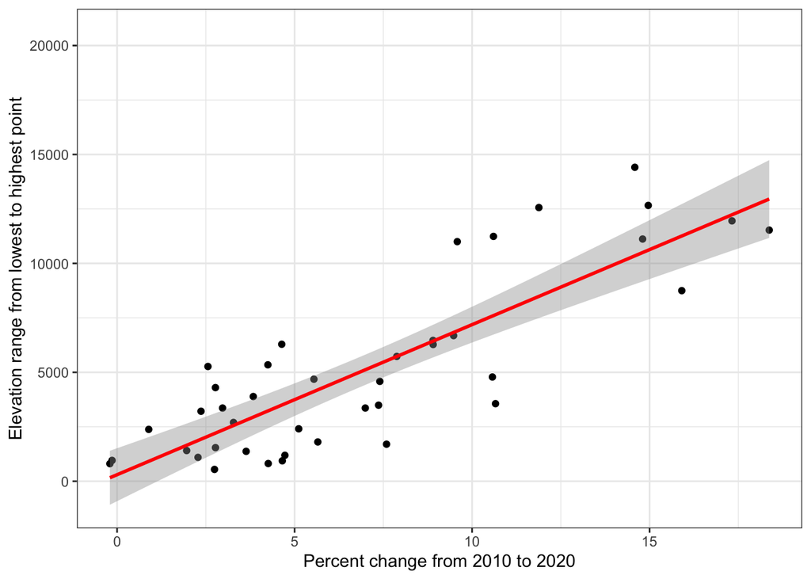

```r
states_to_exclude <- c("Alaska", "California", "Delaware", "District of Columbia", "Florida", "Hawaii", "New Mexico", "North Dakota", "Puerto Rico", "West Virginia", "Wyoming")

filtered_pop_elev <- pop_elev %>%
  filter(!state %in% states_to_exclude)


filtered_pop_elev %>%
  ggplot(aes(x = percent_change_2020, y = elev_range)) +
  geom_point() +
  geom_smooth(method = "lm", se = TRUE, color = "red") +  # Add linear model line
  theme_bw() +
  labs(x="Percent change from 2010 to 2020",
       y="Elevation range from lowest to highest point")
```

```r
#creating the linear model to look at the numbers
model <- lm(percent_change_2020 ~ elev_range, data = filtered_pop_elev)
summary(model)
```

```
##
## Call:
## lm(formula = percent_change_2020 ~ elev_range, data = filtered_pop_elev)
##
## Residuals:
##     Min      1Q  Median      3Q     Max
## -4.5712 -2.6509  0.2753  1.7784  5.2807
##
## Coefficients:
##              Estimate Std. Error t value Pr(>|t|)
## (Intercept) 1.7288578  0.6813286   2.537   0.0153 *
## elev_range  0.0010254  0.0001059   9.685 6.29e-12 ***
## ---
## Signif. codes:  0 '***' 0.001 '**' 0.01 '*' 0.05 '.' 0.1 ' ' 1
##
## Residual standard error: 2.681 on 39 degrees of freedom
##   (9 observations deleted due to missingness)
## Multiple R-squared:  0.7063, Adjusted R-squared:  0.6988
## F-statistic:  93.8 on 1 and 39 DF,  p-value: 6.288e-12
```

After taking out those states the P-value is now 6.288e-12 and the R^2 is 0.706 these show a much better correlation and display very significant results!

## #10

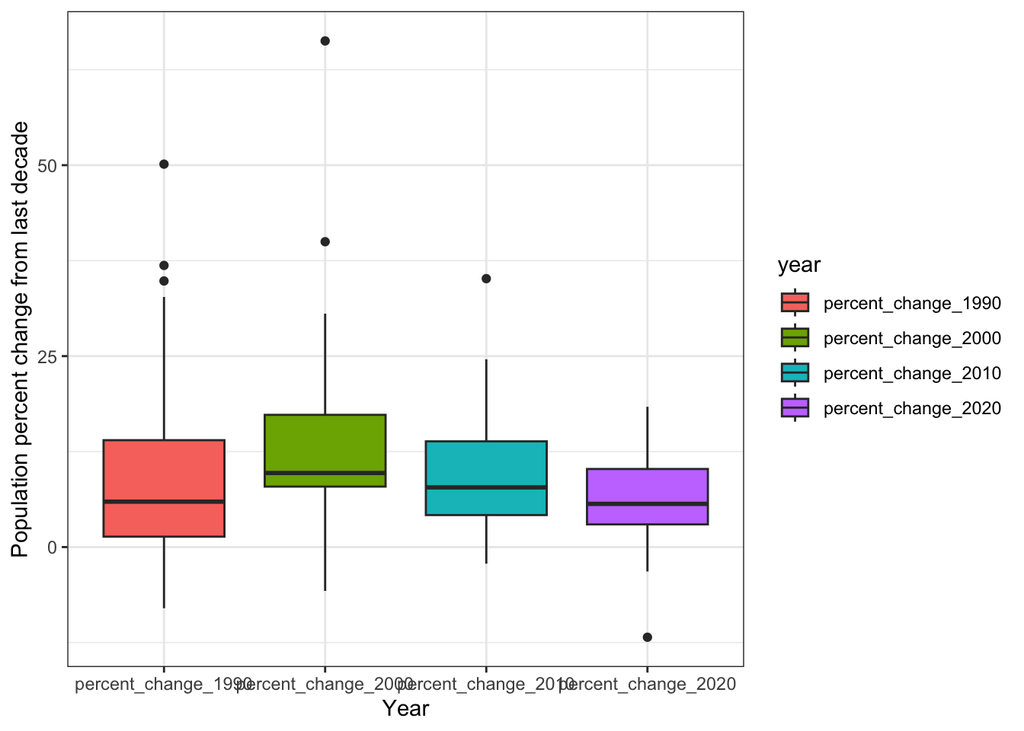

```r
long_pop_elev <- pop_elev %>% pivot_longer(starts_with("percent"),
                          names_to = "year",
                          values_to = "percent_change")

long_pop_elev %>%
  ggplot(aes(x=year,y=percent_change,fill=year)) +
  geom_boxplot() +
  theme_bw() +
  labs(x="Year",
       y="Population percent change from last decade")
```

```r
#im not exactly sure what question 10 is asking
```

I don’t know if I fully understand what question 10 is asking, I’m assuming you’re meaning the consistency of decade percentage growth. This does not stay linear and that makes sense because a 20% growth for a decade and another 20% growth for the next decade makes the next decade an actual 24% growth compared to the starting decade. Population growth is also exponetial and would not be accurately attributed with a linear model.

## #11

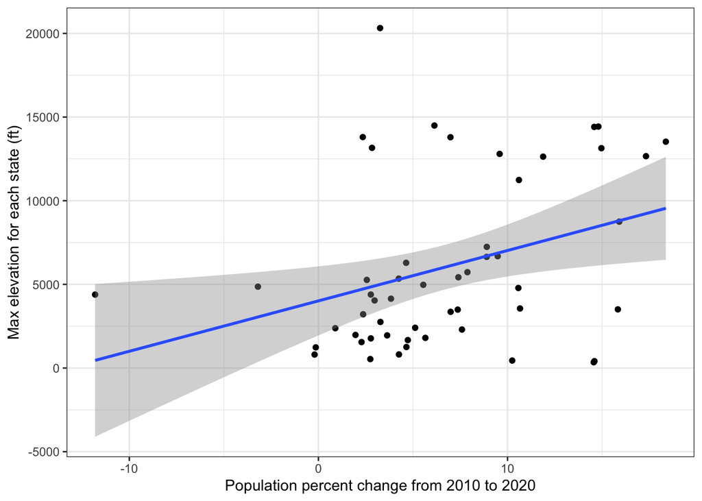

```r
us_temp <- rename(us_temp,state = name)

pop_elev_temp <- full_join(pop_elev,us_temp)

pop_elev_temp %>%
  ggplot(aes(x=percent_change_2020,y=max_elev_ft)) +
  geom_point() +
  geom_smooth(method="lm") +
  theme_bw() +
  labs(x="Population percent change from 2010 to 2020",
       y="Max elevation for each state (ft)")
```

There seems to be a decent correlation between the max elevation found in each state and the population percent increase from 2010 to 2020.

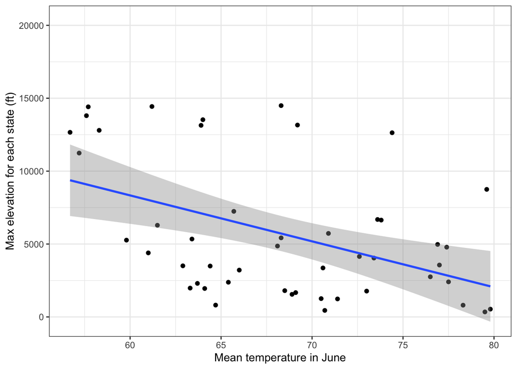

```r
pop_elev_temp %>%
  ggplot(aes(x=june_means,y=max_elev_ft)) +
  geom_point() +
    geom_smooth(method="lm") +
  theme_bw() +
  labs(x="Mean temperature in June",
       y="Max elevation for each state (ft)")
```

There also seems to be a negative correlation between the max elevation for each state and mean temperature in june.